# INFSCI 2595 Final, Part 1a: Exploration (Distribution & Counts)

Sentiment variables

Ben Stein

3/23/2022

# About this document

In this document, I examine the distributions and counts of the variables in the dataset supplied for the final project.

# Setup

## Libraries

```r
library(tidyverse)
```

## Data

```r
df_raw <- readr::read_csv("./final_project_train.csv", col_names = TRUE)
```

## Cleaning

```r
df <- df_raw %>%
  mutate_if(is.character, as.factor)
```

# Distributions and counts

## Predictors: categorical (`region` and `customer`)

```r
df %>%
  select(where(is.factor), -outcome) %>%
  summary()
```

```
##  region      customer
##  XX:161   Other  :245
##  YY:222   G      :113
##  ZZ:294   M      : 71
##           A      : 55
##           B      : 52
##           K      : 38
##           (Other):103
```

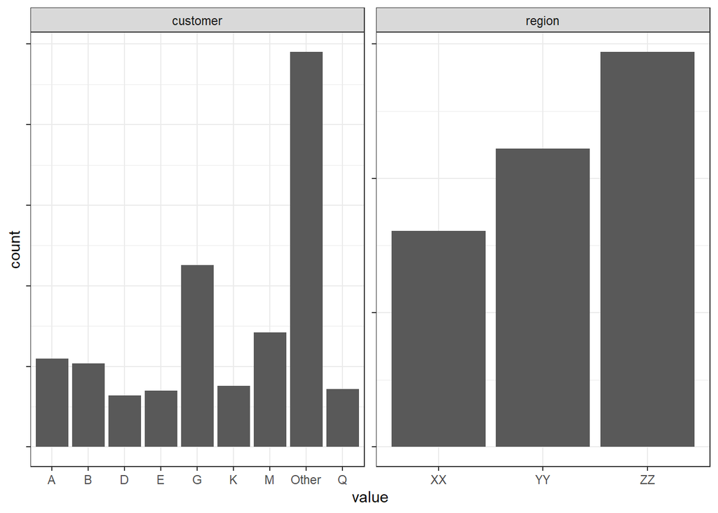

```r
df %>%
  select(where(is.factor), -outcome) %>%
  pivot_longer(cols = everything()) %>%
  ggplot(mapping = aes(x = value)) +
  geom_histogram(stat = "count") +
  facet_wrap(~name, scales = "free") +
  theme_bw() +
  theme(axis.text.y = element_blank())
```

From this, we can see that `Other` is by far the most common category for customers.The three regions present in the dataset occur on roughly the same scale, but region `ZZ` is the most common.

## Continuous predictors (all sentiment-related variables)

```r
visualize_distributions <- function(x, column_name_start) {
  x %>%
    select(starts_with(column_name_start)) %>%
    pivot_longer(cols = everything()) %>%
    ggplot(mapping = aes(x = value)) +
    geom_histogram(bins = 50) +
    facet_wrap(~name, scales = "free") +
    theme_bw() +
    theme(axis.text.y = element_blank())
}
```

### Lexicon: Bing

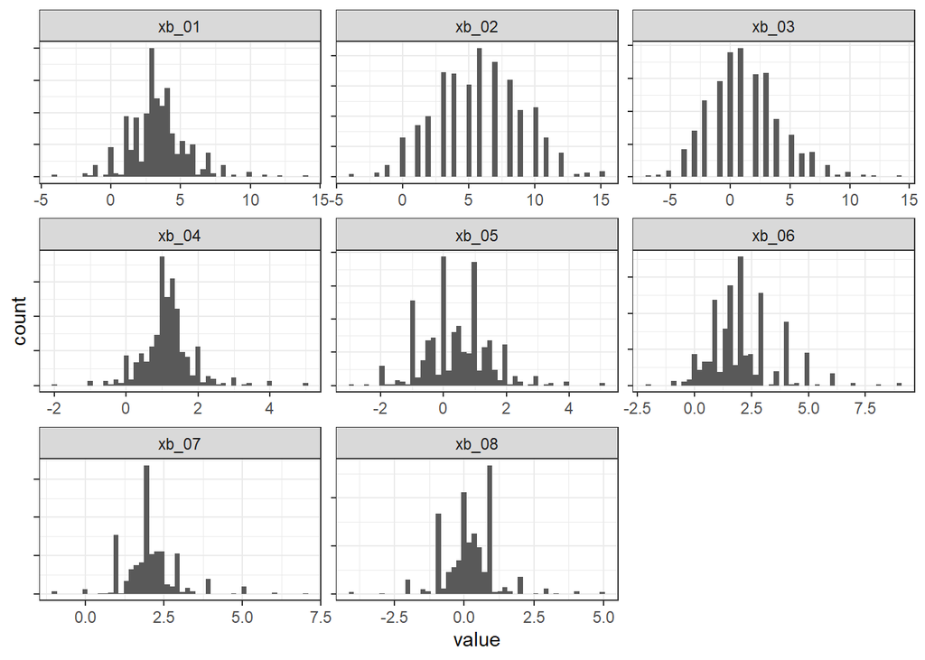

```r
df %>% visualize_distributions("xb_")
```

The figure suggests that most of the Bing lexicon features have approximately Gaussian distribution, though some seem slightly less so (e.g. `xb_05`, `xb_07`, `xb_08`).

### Lexicon: NRC

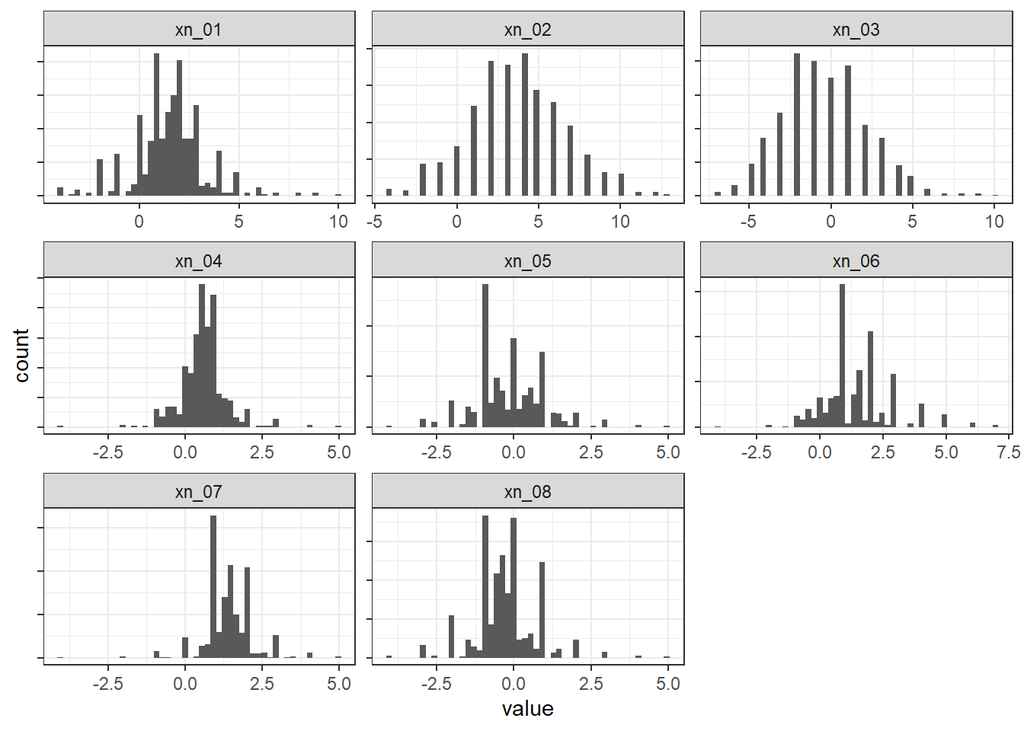

```r
df %>% visualize_distributions("xn_")
```

Similar to the Bing lexicon features, the NRC lexicon features are roughly Gaussian with some possible exceptions (e.g. `xn_07`, and `xn_06` seems slightly right-tailed).

### Lexicon: AFINN

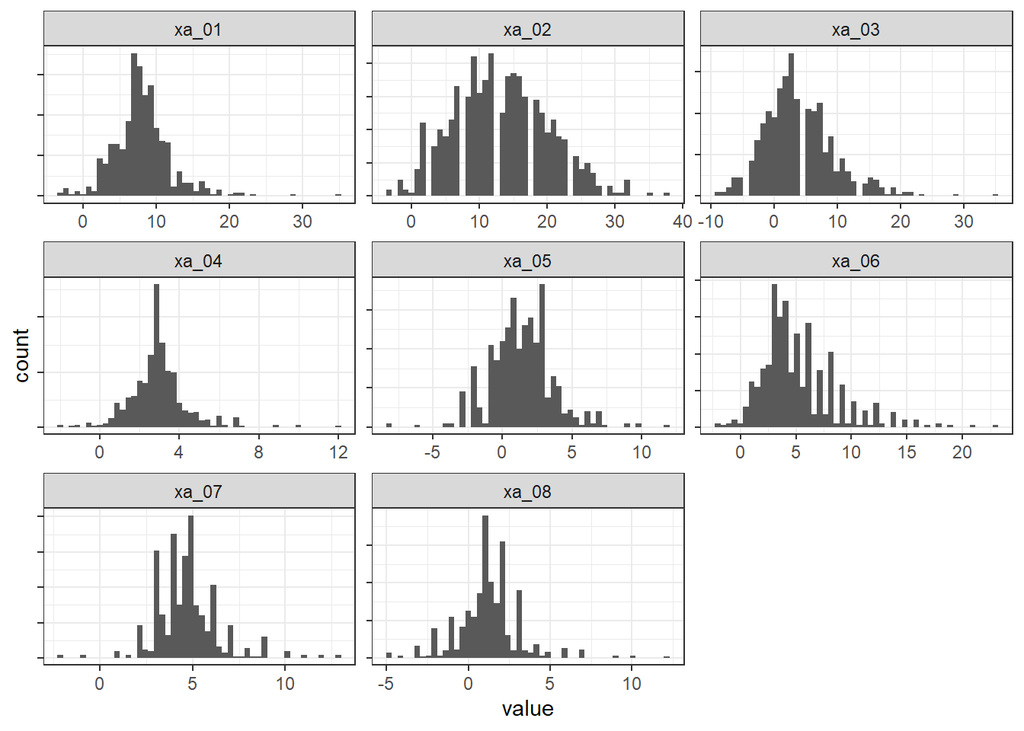

```r
df %>% visualize_distributions("xa_")
```

The AFINN lexicon features appear Gaussian, though `xa_06` seems right-tailed.

### Word-count features

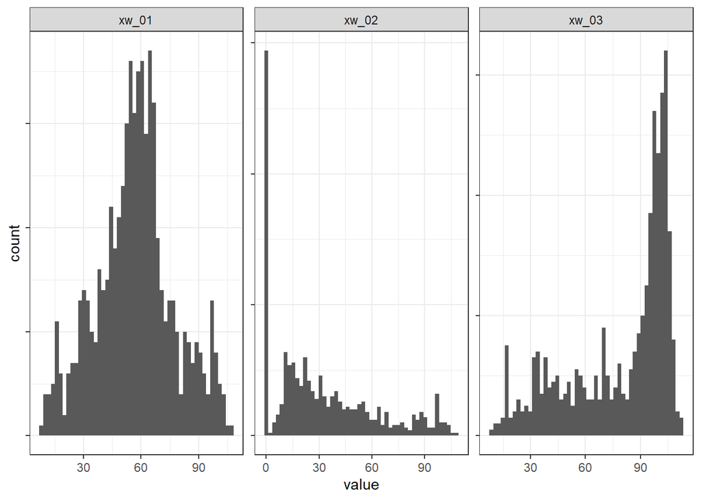

```r
df %>% visualize_distributions("xw_")
```

Only one of the word-count-based features appears Gaussian (`xw_01`). `xw_02`seems right-tailed, while `xw_03` seems left-tailed.

### `sentimentr` features

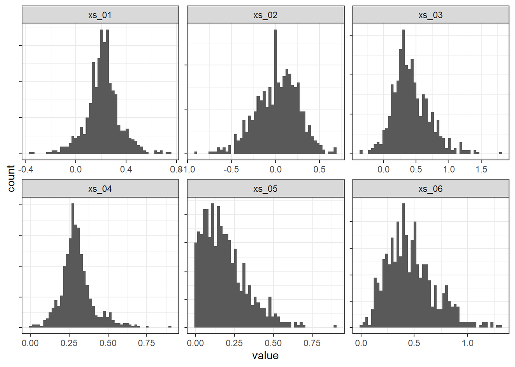

```r
df %>% visualize_distributions("xs_")
```

## Outcome/response variables

We’ll ultimately treat these variables as our prediction targets in regression and classification.

### Outcome

The `outcome` is a binary variable which describes whether a given product failed to meet its sales goal (i.e. a value of `"event"` indicates that it **did not** meet its sales goal).

```r
df$outcome %>% summary
```

```
##     event non_event
##       127       550
```

The `event` outcome seems relatively rare (127 times out of 677 trials, or with about **0.188** probability).

### Response

The `response` variable is continuous describes the number of hours per week are associated with a product being sold to a customer.

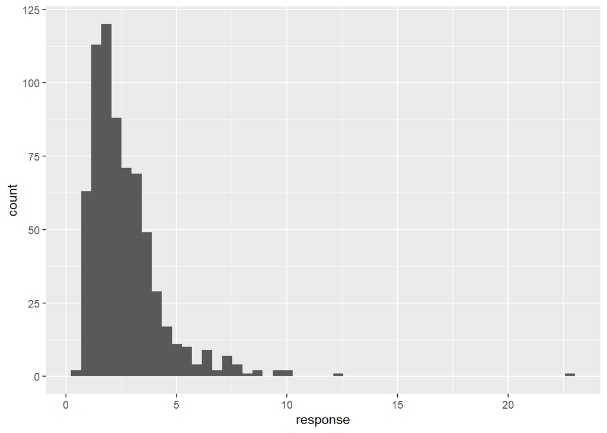

```r
df %>%
  ggplot(mapping = aes(x = response)) +
  geom_histogram(bins = 50)
```

`response` is heavily right-tailed. We can understand this quantitatively by looking at summary distribution statistics.

```r
df %>%
  select(response) %>%
  summary()
```

```
##     response
##  Min.   : 0.5725
##  1st Qu.: 1.5615
##  Median : 2.2896
##  Mean   : 2.6756
##  3rd Qu.: 3.2764
##  Max.   :22.9219
```

This suggests that (independent of the assignment requirements), we probably want to log-transform the variable when modeling. After log transformation, we can see that the distribution appears more normal.

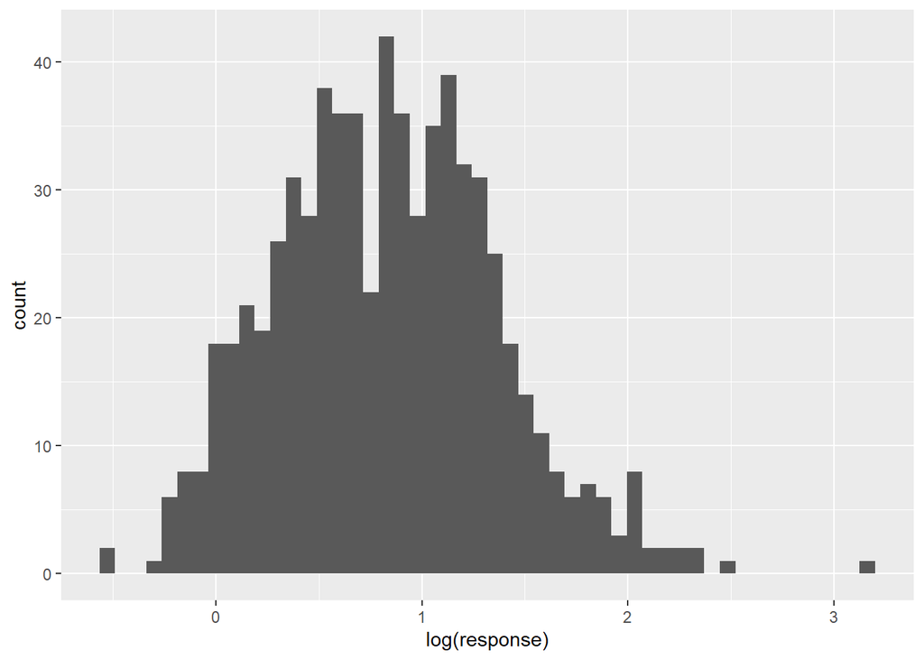

```r
df %>%
  ggplot(mapping = aes(x = log(response))) +
  geom_histogram(bins = 50)
```